## Is There No Making Some People Happy?

### Introduction

There are categories of businesses in the [Yelp! dataset](http://www.yelp.com/dataset_challenge) that may very well transcend the quality of the businesses within them. On average, the businesses within these categories enjoy very high ratings from Yelp! reviewers. Nevertheless, there are those individuals who have assigned to buisinesses within one of these **pleasure** categories at least one review that is at least 1.5 stars lower than the category’s average rating. These people will heretofore be known as the **the miserables**. The inverse is also true: there are those who have assigned at least one rating at least 1.5 stars higher than the average category rating for a business in a **non-pleasure** category. They are **the joyous**.

Are there categories that defy one’s status as **miserable** or **joyous**?

### Methods

Are the **miserables** and the **joyous** all that different? One way to tell from the Yelp! dataset is by the feedback they receive from other Yelp! users. I chose to look at total feedback (a summation of all feedback compliments plus fan and friend counts), hot and funny compliments and the numer of reviews these users write. Drop lines denoting the mean for miserables, the joyous and the total population are blue, red and green, respectively.

Here’s an example of how I produced a sampling of the mean sample by taking the mean of 2,000 samples from each population 100,000 times.

```r
joyous.out <- replicate( 100000, mean( sample(joyous$funny_compliments, 2000) ) )
miserables.out <- replicate( 100000, mean( sample(miserables$funny_compliments, 2000) ) )
avgs.out <- replicate( 100000, mean( sample(avgs$funny_compliments, 2000) ) )
```

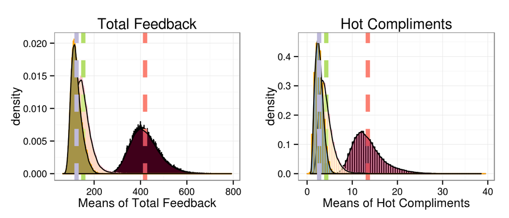

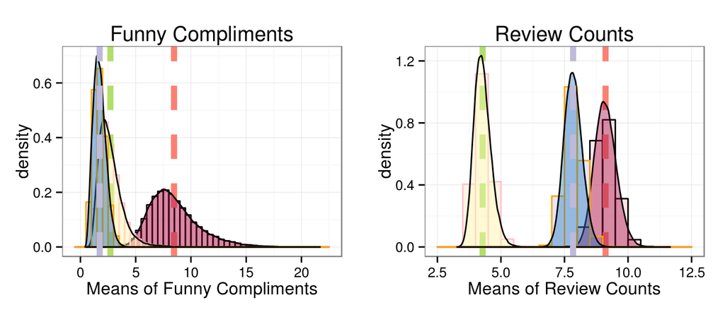

It’s clear that these groups are perceived differently. And Student’s t-Tests confirm these means are indeed different. Of interest though is that though the miserables receive less total feedback and fewer hot and funny compliments than the overall population, they write considerably more reviews than the overall population, though fewer than the joyous.

```r
t.test(as.numeric(df.joyous.out$feedback), as.numeric(df.miserables.out$feedback))$p.value
t.test(as.numeric(df.joyous.out$hot), as.numeric(df.miserables.out$hot))$p.value
t.test(as.numeric(df.joyous.out$funny), as.numeric(df.miserables.out$funny))$p.value
```

[output not shown]

Here are some examples of words more commonly found in **pleasurable** categories than **unpleasurable** categories. Not surprisingly, these words are somewhat affirming – active, life, beauty.

```
##   pleas.category unpleas.category difference pct.difference   name
## 1             45                5         40      0.8000000   hair
## 2             57               19         38      0.5000000   spas
## 3             51               21         30      0.4166667 beauti
## 4             48               22         26      0.3714286    pet
## 5             32                8         24      0.6000000   life
## 6             30                8         22      0.5789474  activ
```

It should be noted that to be considered among the **pleasure** categories, a category must include at least seven businesses and at least 30 reviews. The same is true for inclusion in the **unpleasurable** categories. And words more likely to appear in those can be found below:

```
##   pleas.category unpleas.category difference pct.difference     name
## 1             64              213       -149     -0.5379061  restaur
## 2             18              100        -82     -0.6949153      bar
## 3             11               68        -57     -0.7215190 nightlif
## 4             13               62        -49     -0.6533333 american
## 5              5               44        -39     -0.7959184   tradit
## 6             13               44        -31     -0.5438596    store
```

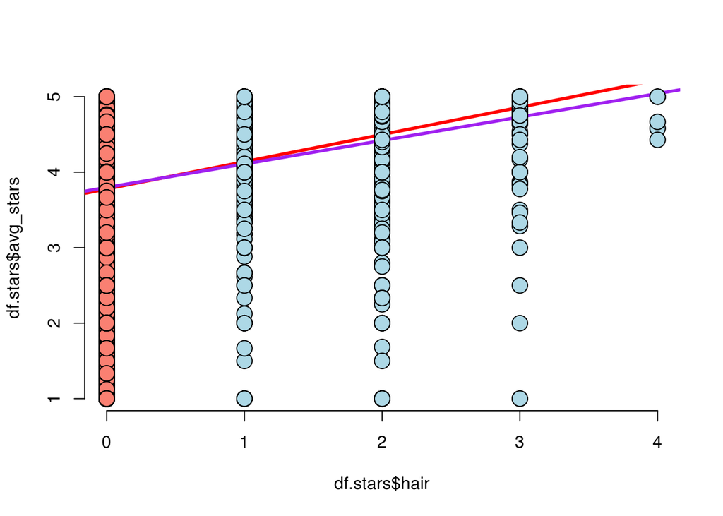

```
##
## Call:
## lm(formula = avg_stars ~ hair * feedback_quadrant, data = df.stars)
##
## Residuals:
##     Min      1Q  Median      3Q     Max
## -3.4706 -0.4803  0.1512  0.7181  1.2024
##
## Coefficients:
##                         Estimate Std. Error t value Pr(>|t|)
## (Intercept)             3.777667   0.015695 240.688  < 2e-16 ***
## hair                    0.360609   0.045407   7.942 2.07e-15 ***
## feedback_quadrant       0.019919   0.005515   3.612 0.000305 ***
## hair:feedback_quadrant -0.049845   0.016724  -2.980 0.002881 **
## ---
## Signif. codes:  0 '***' 0.001 '**' 0.01 '*' 0.05 '.' 0.1 ' ' 1
##
## Residual standard error: 0.9844 on 26194 degrees of freedom
## Multiple R-squared:  0.006839,   Adjusted R-squared:  0.006725
## F-statistic: 60.13 on 3 and 26194 DF,  p-value: < 2.2e-16
```

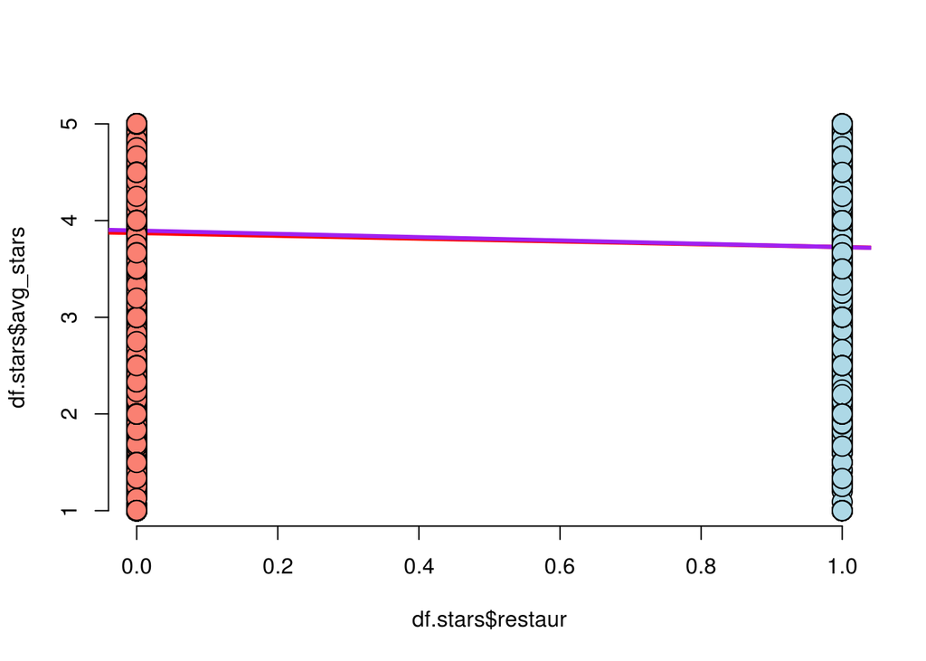

```
##
## Call:
## lm(formula = avg_stars ~ restaur * feedback_quadrant, data = df.stars)
##
## Residuals:
##     Min      1Q  Median      3Q     Max
## -2.9753 -0.4696  0.1510  0.7698  1.2781
##
## Coefficients:
##                           Estimate Std. Error t value Pr(>|t|)
## (Intercept)                3.87054    0.02074 186.577  < 2e-16 ***
## restaur                   -0.14441    0.03093  -4.669 3.04e-06 ***
## feedback_quadrant          0.02619    0.00726   3.607  0.00031 ***
## restaur:feedback_quadrant -0.02724    0.01089  -2.501  0.01240 *
## ---
## Signif. codes:  0 '***' 0.001 '**' 0.01 '*' 0.05 '.' 0.1 ' ' 1
##
## Residual standard error: 0.9817 on 26194 degrees of freedom
## Multiple R-squared:  0.01229,    Adjusted R-squared:  0.01218
## F-statistic: 108.6 on 3 and 26194 DF,  p-value: < 2.2e-16
```

### Results

Upon producing a normalized distribution of sample means, I can compare more clearly the mean values for people in each of the populations. The joyous are represented by the red vertical line, the miserables’ mean is denoted by the blue line and the mean for the total population is marked with a green drop line.

Using a Student’s t-Test, it can be demonstrated that between each population, the population means indeed differ. And in each, case overall feedback is more positive for the joyous population.